# HW02 dplyr exploration

## Exercise 1

### Use filter() to subset the gapminder data to three countries of your choice in the 1970’s.

| country | continent | year | lifeExp | pop | gdpPercap |
| --- | --- | --- | --- | --- | --- |
| Costa Rica | Americas | 1972 | 67.849 | 1834796 | 5118.147 |
| Costa Rica | Americas | 1977 | 70.750 | 2108457 | 5926.877 |
| Egypt | Africa | 1972 | 51.137 | 34807417 | 2024.008 |
| Egypt | Africa | 1977 | 53.319 | 38783863 | 2785.494 |
| Japan | Asia | 1972 | 73.420 | 107188273 | 14778.786 |
| Japan | Asia | 1977 | 75.380 | 113872473 | 16610.377 |

### Use the pipe operator %>% to select “country” and “gdpPercap” from your filtered dataset in 1.1.

| country | gdpPercap |
| --- | --- |
| Costa Rica | 5118.147 |
| Costa Rica | 5926.877 |
| Egypt | 2024.008 |
| Egypt | 2785.494 |
| Japan | 14778.786 |
| Japan | 16610.377 |

### Filter gapminder to all entries that have experienced a drop in life expectancy.

|  | country | continent | year | lifeExp | pop | gdpPercap | Diff_LifeExp |
| --- | --- | --- | --- | --- | --- | --- | --- |
| 1 | Albania | Europe | 1992 | 71.581 | 3326498 | 2497.437901 | -0.418999999999997 |
| 2 | Angola | Africa | 1987 | 39.906 | 7874230 | 2430.208311 | -0.0360000000000014 |
| 3 | Benin | Africa | 2002 | 54.406 | 7026113 | 1372.877931 | -0.371000000000002 |
| 4 | Botswana | Africa | 1992 | 62.745 | 1342614 | 7954.111645 | -0.877000000000002 |
| 5 | Botswana | Africa | 1997 | 52.556 | 1536536 | 8647.142313 | -10.189 |
| 6 | Botswana | Africa | 2002 | 46.634 | 1630347 | 11003.60508 | -5.922 |
| 7 | Bulgaria | Europe | 1977 | 70.81 | 8797022 | 7612.240438 | -0.0900000000000034 |
| 8 | Bulgaria | Europe | 1992 | 71.19 | 8658506 | 6302.623438 | -0.150000000000006 |
| 9 | Bulgaria | Europe | 1997 | 70.32 | 8066057 | 5970.38876 | -0.870000000000005 |
| 10 | Burundi | Africa | 1992 | 44.736 | 5809236 | 631.6998778 | -3.475 |

[output cut: 92 more lines]

### Filter gapminder to contain six rows: the rows with the three largest GDP per capita, and the rows with the three smallest GDP per capita.

```r
gapminder %>%
  arrange(gdpPercap) %>%  # arranges in ascending order
  slice(-4:-(n()-3)) %>% # drops all rows from 4 to [(last row)-3], leaving first and last 3
  kable(align="c")
```

| country | continent | year | lifeExp | pop | gdpPercap |
| --- | --- | --- | --- | --- | --- |
| Congo, Dem. Rep. | Africa | 2002 | 44.966 | 55379852 | 241.1659 |
| Congo, Dem. Rep. | Africa | 2007 | 46.462 | 64606759 | 277.5519 |
| Lesotho | Africa | 1952 | 42.138 | 748747 | 298.8462 |
| Kuwait | Asia | 1952 | 55.565 | 160000 | 108382.3529 |
| Kuwait | Asia | 1972 | 67.712 | 841934 | 109347.8670 |
| Kuwait | Asia | 1957 | 58.033 | 212846 | 113523.1329 |

### Produce a scatterplot of Canada’s life expectancy vs. GDP per capita using ggplot2, without defining a new variable.

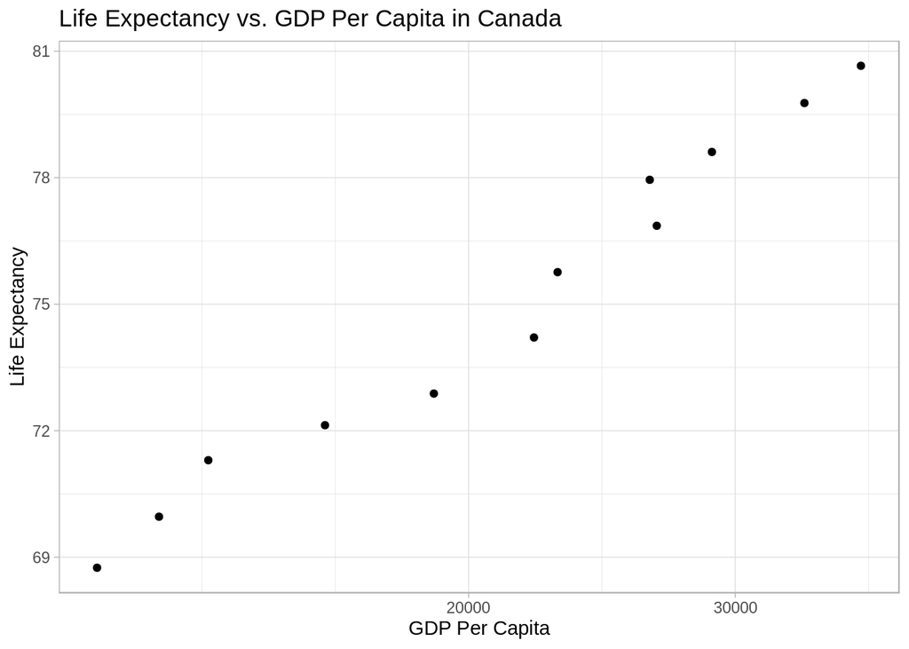

```r
gapminder %>%
  filter(country == "Canada") %>%
  ggplot(aes(x=gdpPercap, y = lifeExp)) +
  geom_point() +
  scale_x_log10("GDP Per Capita") +
  ylab("Life Expectancy") +
  ggtitle("Life Expectancy vs. GDP Per Capita in Canada") +
  theme_light()
```

##Exercise 2

### Exploring categorical (country) and quantitative (population) variables

Population data:

```r
gapminder %>%
  summarize(mean_pop = mean(pop),
            highest_pop = max(pop),
            min_pop = min(pop),
            sd_pop = sd(pop),
            pop_range = (range(pop))[2] - (range(pop))[1],
            num_countries = length(unique(country))) %>%
             kable(align="c")
```

| mean_pop | highest_pop | min_pop | sd_pop | pop_range | num_countries |
| --- | --- | --- | --- | --- | --- |
| 29601212 | 1318683096 | 60011 | 106157897 | 1318623085 | 142 |

Population by country:

```r
gapminder %>%
  group_by(country) %>%
  summarize(mean_pop = mean(pop),
            highest_pop = max(pop),
            lowest_pop = min(pop),
            sd_pop = sd(pop),
            range = (range(pop))[2] - (range(pop))[1],
            year_highest_pop = year[pop == highest_pop],
            year_lowest_pop = year[pop == lowest_pop]) %>%
   datatable()
```

|  | country | mean_pop | highest_pop | lowest_pop | sd_pop | range | year_highest_pop | year_lowest_pop |
| --- | --- | --- | --- | --- | --- | --- | --- | --- |
| 1 | Afghanistan | 15823715.4166667 | 31889923 | 8425333 | 7114583.47431877 | 23464590 | 2007 | 1952 |
| 2 | Albania | 2580249.16666667 | 3600523 | 1282697 | 828585.541696081 | 2317826 | 2007 | 1952 |
| 3 | Algeria | 19875406.1666667 | 33333216 | 9279525 | 8613355.34416447 | 24053691 | 2007 | 1952 |
| 4 | Angola | 7309390.08333333 | 12420476 | 4232095 | 2672280.58533307 | 8188381 | 2007 | 1952 |
| 5 | Argentina | 28602239.9166667 | 40301927 | 17876956 | 7546608.98902828 | 22424971 | 2007 | 1952 |
| 6 | Australia | 14649312.5 | 20434176 | 8691212 | 3915202.96477682 | 11742964 | 2007 | 1952 |
| 7 | Austria | 7583298.41666667 | 8199783 | 6927772 | 437659.982043233 | 1272011 | 2007 | 1952 |
| 8 | Bahrain | 373913.166666667 | 708573 | 120447 | 210893.261610458 | 588126 | 2007 | 1952 |
| 9 | Bangladesh | 90755395.3333333 | 150448339 | 46886859 | 34711660.6898279 | 103561480 | 2007 | 1952 |
| 10 | Belgium | 9725118.66666667 | 10392226 | 8730405 | 520635.932944481 | 1661821 | 2007 | 1952 |

[output cut: 132 more lines]

Graphing world population vs. year, where color = continent and size = GDP per capita.

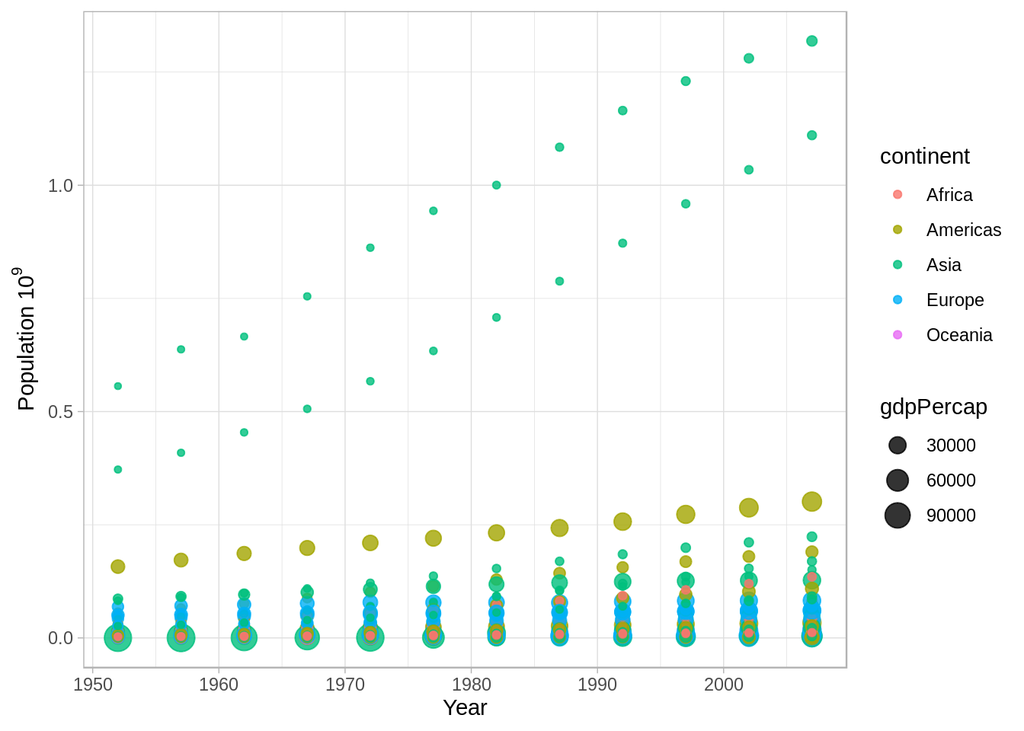

```r
gapminder %>%
  group_by(continent) %>%
  mutate(pop = pop/1000000000) %>%
  ggplot(aes(x=year, y=pop, color=continent, size=gdpPercap)) +
  geom_point(alpha=0.8) +
  xlab("Year") +
  ylab(expression(paste("Population ", 10^9))) +
  theme_light()
```

Graphing countries with populations over 50 million in 1952

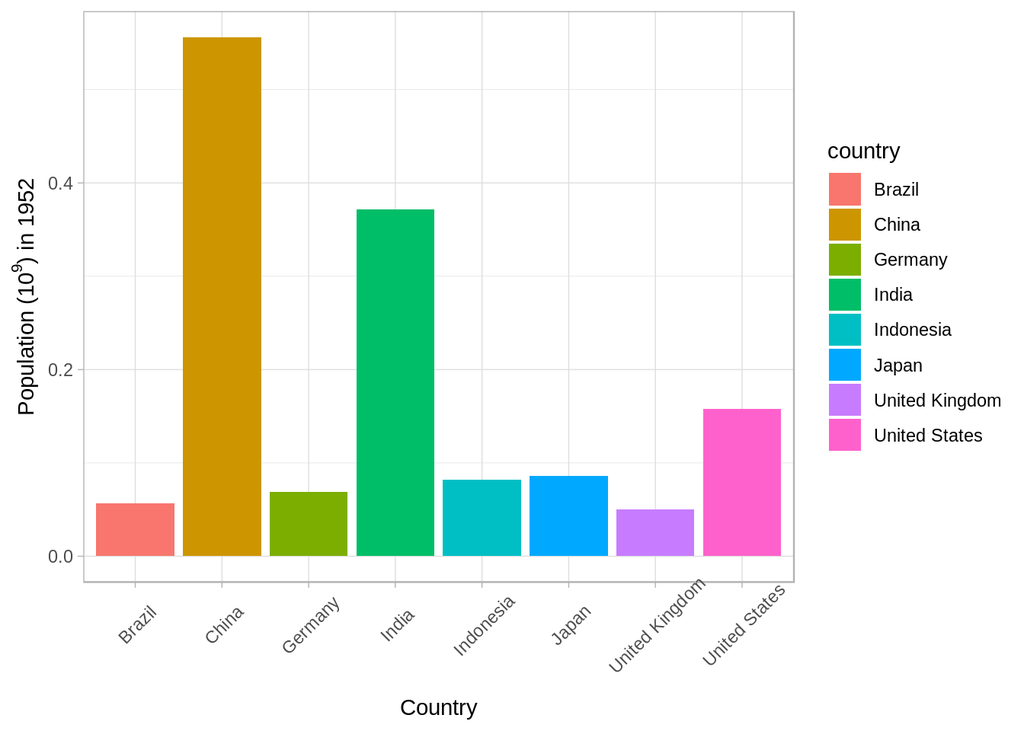

```r
gapminder %>%
  filter(pop > 50000000 & year == 1952) %>%
   mutate(pop = pop/1000000000) %>%
  ggplot(aes(x=country, y=pop, fill=country)) +
  geom_bar(stat="identity") +
  xlab("Country") +
  ylab(expression(paste("Population (", 10^9, ") in 1952"))) +
  theme_light() +
  theme(axis.text.x=element_text(angle=45, vjust=0.7))
```

## Exercise 3

### Make two plots that have some value to them

1. Scatter plot: Quantitative variables year, population, life expectancy.

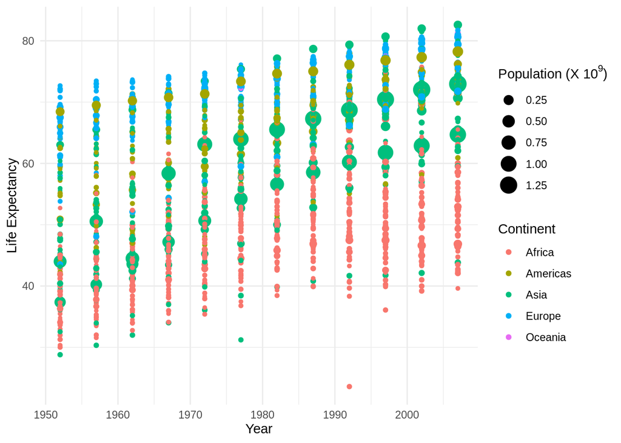

```r
gapminder %>%
  mutate(pop=pop/1000000000) %>%
  ggplot(aes(x=year, y=lifeExp, size = pop, color=continent)) +
  geom_point() +
  theme_minimal() +
  ylab("Life Expectancy") +
  xlab("Year")+
  scale_size_continuous(name=expression(paste("Population (X ", 10^9,")"))) +
  scale_color_discrete(name="Continent")
```

2. Non-scatter plot: Life expectancy vs year for countries in Africa

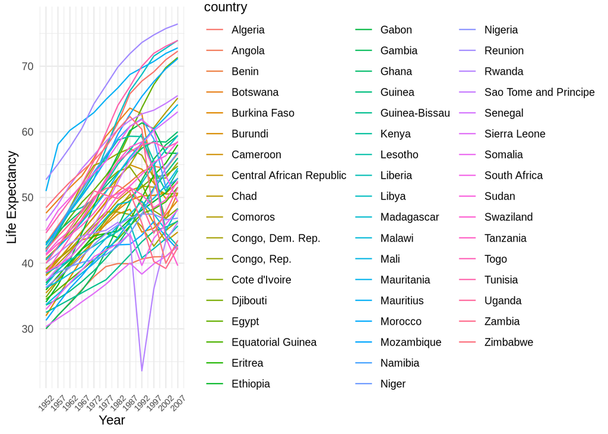

```r
  gapminder %>%
    filter(continent == "Africa") %>%
    ggplot(aes(x=year, y=lifeExp, color=country)) +
    geom_line() +
    ylab("Life Expectancy") +
    xlab("Year") +
    scale_x_continuous(breaks = seq(1952, 2007, by = 5)) +
    theme_minimal() +
    theme(axis.text.x=element_text(angle=45, vjust=0.5, size=7))
```

## Optional: Recycling

### Presumably the analyst’s intent was to get the data for Rwanda and Afghanistan. Did they succeed? Why or why not? If not, what is the correct way to do this?

```r
filter(gapminder, country == c("Rwanda", "Afghanistan"))
```

```
## # A tibble: 12 x 6
##    country     continent  year lifeExp      pop gdpPercap
##    <fct>       <fct>     <int>   <dbl>    <int>     <dbl>
##  1 Afghanistan Asia       1957    30.3  9240934      821.
##  2 Afghanistan Asia       1967    34.0 11537966      836.
##  3 Afghanistan Asia       1977    38.4 14880372      786.
##  4 Afghanistan Asia       1987    40.8 13867957      852.
##  5 Afghanistan Asia       1997    41.8 22227415      635.
##  6 Afghanistan Asia       2007    43.8 31889923      975.
##  7 Rwanda      Africa     1952    40    2534927      493.
##  8 Rwanda      Africa     1962    43    3051242      597.
##  9 Rwanda      Africa     1972    44.6  3992121      591.
## 10 Rwanda      Africa     1982    46.2  5507565      882.
## 11 Rwanda      Africa     1992    23.6  7290203      737.
## 12 Rwanda      Africa     2002    43.4  7852401      786.
```

This way does not suceed in selecting all rows with these countries, this prints only half of the number of rows corresponding to these countries.

The correct to get all the data from these countries would be:

```r
filter(gapminder, country %in% c("Rwanda", "Afghanistan"))
```

```
## # A tibble: 24 x 6
##    country     continent  year lifeExp      pop gdpPercap
##    <fct>       <fct>     <int>   <dbl>    <int>     <dbl>
##  1 Afghanistan Asia       1952    28.8  8425333      779.
##  2 Afghanistan Asia       1957    30.3  9240934      821.
##  3 Afghanistan Asia       1962    32.0 10267083      853.
##  4 Afghanistan Asia       1967    34.0 11537966      836.
##  5 Afghanistan Asia       1972    36.1 13079460      740.
##  6 Afghanistan Asia       1977    38.4 14880372      786.
##  7 Afghanistan Asia       1982    39.9 12881816      978.
##  8 Afghanistan Asia       1987    40.8 13867957      852.
##  9 Afghanistan Asia       1992    41.7 16317921      649.
## 10 Afghanistan Asia       1997    41.8 22227415      635.
## # … with 14 more rows
```

an alternative way:

```r
filter(gapminder, country == "Rwanda" | country =="Afghanistan")
```

```
## # A tibble: 24 x 6
##    country     continent  year lifeExp      pop gdpPercap
##    <fct>       <fct>     <int>   <dbl>    <int>     <dbl>
##  1 Afghanistan Asia       1952    28.8  8425333      779.
##  2 Afghanistan Asia       1957    30.3  9240934      821.
##  3 Afghanistan Asia       1962    32.0 10267083      853.
##  4 Afghanistan Asia       1967    34.0 11537966      836.
##  5 Afghanistan Asia       1972    36.1 13079460      740.
##  6 Afghanistan Asia       1977    38.4 14880372      786.
##  7 Afghanistan Asia       1982    39.9 12881816      978.
##  8 Afghanistan Asia       1987    40.8 13867957      852.
##  9 Afghanistan Asia       1992    41.7 16317921      649.
## 10 Afghanistan Asia       1997    41.8 22227415      635.
## # … with 14 more rows
```